Note

Go to the end to download the full example code or to run this example in your browser via JupyterLite or Binder.

# Successive Halving Iterations

This example illustrates how a successive halving search (`HalvingGridSearchCV` and `HalvingRandomSearchCV`) iteratively chooses the best parameter combination out of multiple candidates.

```
# Authors: The scikit-learn developers
# SPDX-License-Identifier: BSD-3-Clause

import matplotlib.pyplot as plt
import numpy as np
import pandas as pd
from scipy.stats import randint

from sklearn import datasets
from sklearn.ensemble import RandomForestClassifier
from sklearn.experimental import enable_halving_search_cv  # noqa: F401
from sklearn.model_selection import HalvingRandomSearchCV
```

We first define the parameter space and train a `HalvingRandomSearchCV` instance.

```
rng = np.random.RandomState(0)

X, y = datasets.make_classification(n_samples=400, n_features=12, random_state=rng)

clf = RandomForestClassifier(n_estimators=20, random_state=rng)

param_dist = {
    "max_depth": [3, None],
    "max_features": randint(1, 6),
    "min_samples_split": randint(2, 11),
    "bootstrap": [True, False],
    "criterion": ["gini", "entropy"],
}

rsh = HalvingRandomSearchCV(
    estimator=clf, param_distributions=param_dist, factor=2, random_state=rng
)
rsh.fit(X, y)
```

```
HalvingRandomSearchCV(estimator=RandomForestClassifier(n_estimators=20,
                                                       random_state=RandomState(MT19937) at 0x784166B66A40),
                      factor=2,
                      param_distributions={'bootstrap': [True, False],
                                           'criterion': ['gini', 'entropy'],
                                           'max_depth': [3, None],
                                           'max_features': <scipy.stats._distn_infrastructure.rv_discrete_frozen object at 0x784129d35e50>,
                                           'min_samples_split': <scipy.stats._distn_infrastructure.rv_discrete_frozen object at 0x78416c563490>},
                      random_state=RandomState(MT19937) at 0x784166B66A40)
```

We can now use the `cv_results_` attribute of the search estimator to inspect and plot the evolution of the search.

```
results = pd.DataFrame(rsh.cv_results_)
results["params_str"] = results.params.apply(str)
results.drop_duplicates(subset=("params_str", "iter"), inplace=True)
mean_scores = results.pivot(
    index="iter", columns="params_str", values="mean_test_score"
)
ax = mean_scores.plot(legend=False, alpha=0.6)

labels = [
    f"iter={i}\nn_samples={rsh.n_resources_[i]}\nn_candidates={rsh.n_candidates_[i]}"
    for i in range(rsh.n_iterations_)
]

ax.set_xticks(range(rsh.n_iterations_))
ax.set_xticklabels(labels, rotation=45, multialignment="left")
ax.set_title("Scores of candidates over iterations")
ax.set_ylabel("mean test score", fontsize=15)
ax.set_xlabel("iterations", fontsize=15)
plt.tight_layout()
plt.show()
```

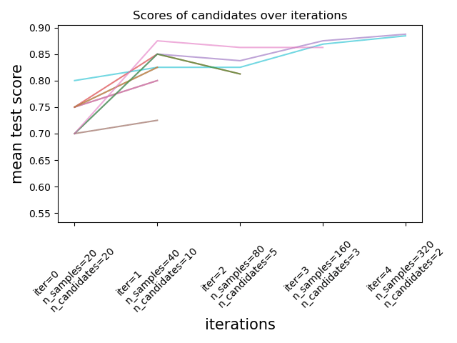

## Number of candidates and amount of resource at each iteration

At the first iteration, a small amount of resources is used. The resource here is the number of samples that the estimators are trained on. All candidates are evaluated.

At the second iteration, only the best half of the candidates is evaluated. The number of allocated resources is doubled: candidates are evaluated on twice as many samples.

This process is repeated until the last iteration, where only 2 candidates are left. The best candidate is the candidate that has the best score at the last iteration.

**Total running time of the script:** (0 minutes 7.454 seconds)

[figure not shown]

[`Download Jupyter notebook: plot_successive_halving_iterations.ipynb`](https://scikit-learn.org/1.9/_downloads/23fb33f64b3c23edf25165a3a4f04237/plot_successive_halving_iterations.ipynb)

[`Download Python source code: plot_successive_halving_iterations.py`](https://scikit-learn.org/1.9/_downloads/49fae0b4f6ab58738dcbf62236756548/plot_successive_halving_iterations.py)

[`Download zipped: plot_successive_halving_iterations.zip`](https://scikit-learn.org/1.9/_downloads/20f62896d2f883bba3587708f3e8a82a/plot_successive_halving_iterations.zip)

#### Related examples

Comparing randomized search and grid search for hyperparameter estimation

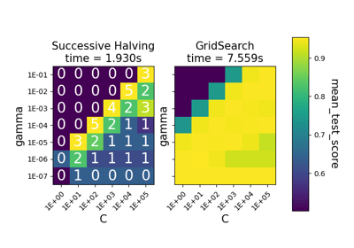

Comparison between grid search and successive halving

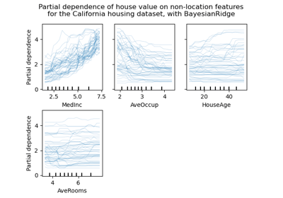

Release Highlights for scikit-learn 0.24

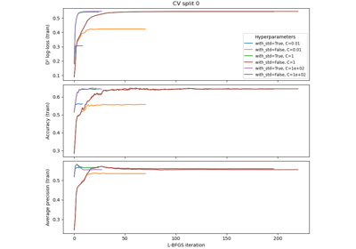

Analysis of the convergence of penalized logistic regression models

© 2007–2026 The scikit-learn developers  
Licensed under the 3-clause BSD License.  
https://scikit-learn.org/1.9/auto_examples/model_selection/plot_successive_halving_iterations.html